# Analysis of GT-rich gene cluster specific to clade B

Stijn Wittouck

15th of June 2017

```r
library(tidyverse)
library(stringr)
source("function_make_clusterTable.R")
source("function_make_arrowPlotTable.R")
source("function_order_contigs.R")
```

# 1 Data preparation

We start by loading all tables we will need:

- **T_gene** (the version with gene coordinates in the genome (as opposed to in the contigs))
- **T_contig** (the version with contig coordinates in the genomes)
- **T_genome**
- **T_orthogroup**

```r
load(file = "intermediate/T_gene_withCo.Robject")
load(file = "intermediate/T_contig_withCo.Robject")
load(file = "intermediate/T_genome.Robject")
load(file = "intermediate/T_orthogroup.Robject")
```

Let’s make a view (a secondary table derived from primary tables) that is basically a large gene table with all possible info, with strain and genome names ordered according to the tree and a new variable “geneFunction” that is equal to cazyFam but that we can extend later (e.g. secretion systems).

```r
V_gene_large <- left_join(T_gene_withCo, T_orthogroup) %>%
  left_join(T_genome) %>%
  left_join(T_contig_withCo) %>%
  mutate(geneFunction = str_replace(cazyFam, ".hmm", "")) %>%
  within(geneFunction[is.na(geneFunction)] <- "unknown")
```

# 2 Clade B specific GT-rich gene cluster

Something very interesting is that both long gene 1 one and long gene 2 are very enriched in Ser risidues. The baseline frequency of Ser is 8.1%. In AMBR2, long gene 1 has 15% Ser residues (457 out of 2955) and long gene 2 38% (2802 out of 7370).

We will add some functional information to the data to use in the plots, based on Prokka functional annotation, BLAST searches.

```r
orthogroupsLongGene1 <- c("OG0004255", "OG0005234")
orthogroupsSecretionSystem <- c("OG0002235", "OG0003634", "OG0003674", "OG0003727", "OG0003893")

V_gene_large <- within(V_gene_large, expr = {
  geneFunction[orthogroup %in% orthogroupsLongGene1] <- "srr1"
  geneFunction[orthogroup == "OG0003635"] <- "srr2"
  geneFunction[orthogroup %in% orthogroupsSecretionSystem] <- "SecA2/SecY2 system"
  geneFunction[orthogroup == "OG0000546"] <- "methionine aminopeptidase"
  geneFunction[orthogroup == "OG0001215"] <- "phosphomevalonate kinase"
  geneFunction[orthogroup == "OG0000733"] <- "transferase"
})
```

```r
V_GtCluster = V_gene_large %>%
  filter(clade == "cladeB") %>%
  make_clusterTable(orthogroup = "OG0001645", before = -4500, after = 57000)
```

Now we can plot the gene cluster:

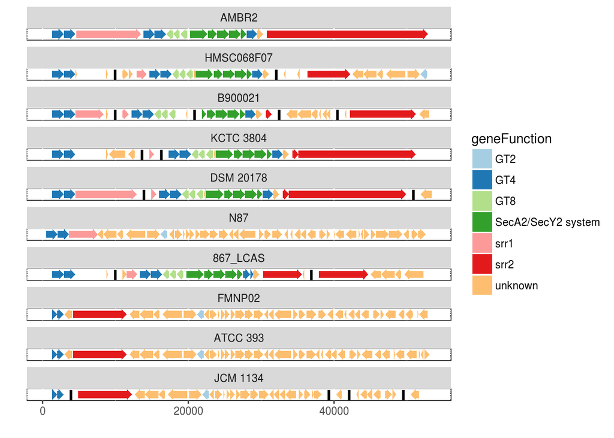

```r
V_GtCluster_forPlot = make_arrowPlotTable(V_GtCluster)  %>%
  mutate(geneFunction = ifelse(str_detect(geneFunction, "GH"), "unknown", geneFunction))

ggplot(V_GtCluster_forPlot, aes(x = x, y = y, group = gene, fill = geneFunction)) +
  geom_polygon() +
  geom_vline(aes(xintercept = contig_start), linetype = 2, size = 1) +
  scale_fill_brewer(palette = "Paired") +
  facet_wrap(~ strain_ordered, scales = "fixed", ncol = 1) +
  xlab("") + ylab("") +
  theme(panel.background = element_rect(fill = 'white', colour = 'black'),
        axis.text.y = element_blank(),
        axis.ticks.y = element_blank())
```

```r
ggsave(filename = "results/GT_rich_cluster_cladeB.png", height = 25, width = 50, units = "cm")
```

These orthogroups have the following distributions over the genomes:

```r
V_nGenomesWithOrthogroup = T_gene_withCo %>%
  select(orthogroup, genome) %>%
  mutate(orthogroup = ifelse(orthogroup == "OG0005234", "OG0004255", orthogroup)) %>%
  distinct() %>%
  left_join(T_genome) %>%
  group_by(orthogroup, clade) %>%
  summarize(nGenomes = n()) %>%
  spread(key = clade, value = nGenomes, fill = 0)

V_GtCluster_orthogroupDistributions <- V_GtCluster %>%
  filter(genome == "AMBR2") %>%
  arrange(start_inGenome) %>%
  mutate(position = 1:n()) %>%
  mutate(geneLength = stop - start + 1) %>%
  select(position, geneFunction, orthogroup, eggnogFam, geneLength) %>%
  left_join(V_nGenomesWithOrthogroup)

options(tibble.print_max = Inf)
V_GtCluster_orthogroupDistributions
```

```
## # A tibble: 16 x 8
##    position       geneFunction orthogroup   eggnogFam geneLength cladeA
##       <int>              <chr>      <chr>       <chr>      <dbl>  <dbl>
##  1        1                GT4  OG0000015 ENOG4104VDV       1587     69
##  2        2                GT4  OG0000016 ENOG4104X0R       1566     70
##  3        3               srr1  OG0004255        <NA>       8868      0
##  4        4                GT4  OG0004134 ENOG4104X0R       1521      1
##  5        5                GT4  OG0004135 ENOG4104VDV       1554      1
##  6        6                GT8  OG0002737 ENOG4104Y5N        906      3
##  7        7                GT8  OG0002737 ENOG4104Y5N        900      3
##  8        8                GT8  OG0002737 ENOG4104Y5N        924      3
##  9        9 SecA2/SecY2 system  OG0002235 ENOG4104T75       2391     39
## 10       10 SecA2/SecY2 system  OG0003634 ENOG4104V88       1224      6
## 11       11 SecA2/SecY2 system  OG0003674 ENOG4104UR7       1638      6
## 12       12 SecA2/SecY2 system  OG0003727 ENOG4104TJU       1635      5
## 13       13 SecA2/SecY2 system  OG0003893 ENOG4104Y1H        765      2
## 14       14                GT4  OG0003599 ENOG4104SWB       1443      8
## 15       15            unknown  OG0003557 ENOG4104XKI        861      8
## 16       16               srr2  OG0003635 ENOG4104X2K      22113      2
## # ... with 2 more variables: cladeB <dbl>, cladeC <dbl>
```

```r
options(tibble.print_max = 10)

write_csv(V_GtCluster_orthogroupDistributions, path = "results/cladeBSpecificGtClusterOrthogroupDistributions.csv")
```

Long gene 2 is also present in two clade A genomes! What’s that all about?!

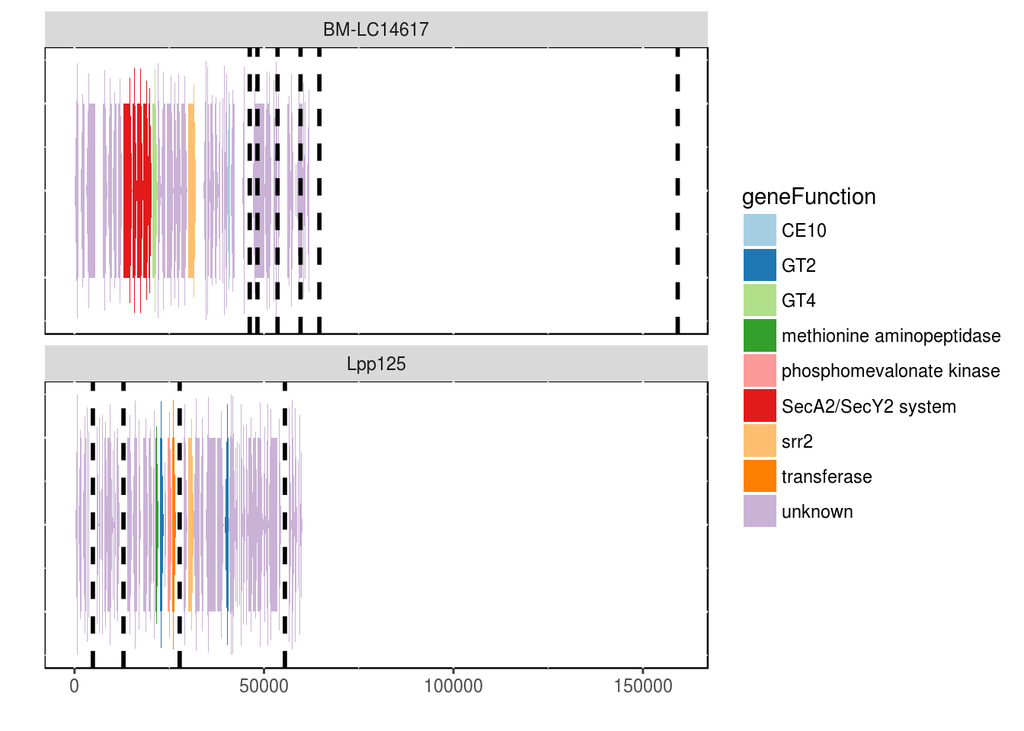

```r
V_GtCluster = V_gene_large %>%
  filter(clade == "cladeA") %>%
  make_clusterTable(orthogroup = "OG0003635", before = 30000, after = 30000)

V_GtCluster_forPlot = make_arrowPlotTable(V_GtCluster)  %>%
  mutate(geneFunction = ifelse(str_detect(geneFunction, "GH"), "unknown", geneFunction))

ggplot(V_GtCluster_forPlot, aes(x = x, y = y, group = gene, fill = geneFunction)) +
  geom_polygon() +
  geom_vline(aes(xintercept = contig_start), linetype = 2, size = 1) +
  scale_fill_brewer(palette = "Paired") +
  facet_wrap(~ strain_ordered, scales = "fixed", ncol = 1) +
  xlab("") + ylab("") +
  theme(panel.background = element_rect(fill = 'white', colour = 'black'),
        axis.text.y = element_blank(),
        axis.ticks.y = element_blank())
```

```r
ggsave(filename = "results/longGene2_cladeA.png", height = 25, width = 50, units = "cm")
```

In one of these, there is also a secretion system and a GT4! In the other one, this might also be the case, but unfortunately a contig boundary prevents us from assassing this.

Let’s check out the secretion system in context everywhere where it is present. We use the SecY2 orthogroup as reference, because we are not interested in the “sole SecA2” system.

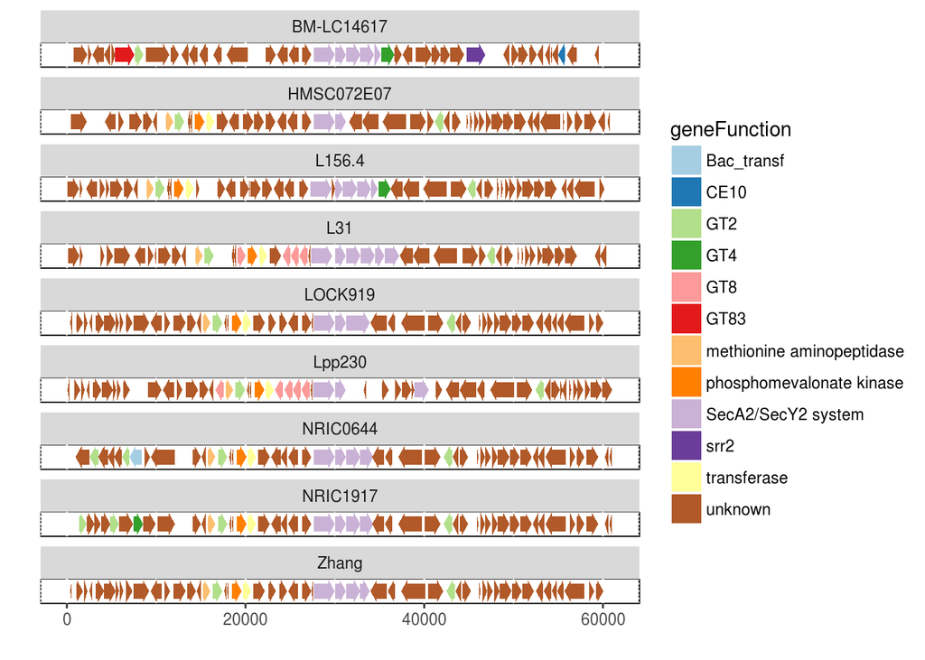

```r
V_GtCluster = V_gene_large %>%
  filter(clade %in% c("cladeA", "cladeC")) %>%
  make_clusterTable(orthogroup = "OG0003634", before = 30000, after = 30000)

V_GtCluster_forPlot = make_arrowPlotTable(V_GtCluster)  %>%
  mutate(geneFunction = ifelse(str_detect(geneFunction, "GH"), "unknown", geneFunction))

ggplot(V_GtCluster_forPlot, aes(x = x, y = y, group = gene, fill = geneFunction)) +
  geom_polygon() +
  # geom_vline(aes(xintercept = contig_start), linetype = 2, size = 1) +
  scale_fill_brewer(palette = "Paired") +
  facet_wrap(~ strain, scales = "fixed", ncol = 1) +
  xlab("") + ylab("") +
  theme(panel.background = element_rect(fill = 'white', colour = 'black'),
        axis.text.y = element_blank(),
        axis.ticks.y = element_blank())
```

```r
ggsave(filename = "results/secretionSystem_cladesAC.png", height = 25, width = 50, units = "cm")
```